# HW5

Seonyoung Park (sp3804)

11/17/2020

```r
library(tidyverse)
library(dplyr)
library(rvest)
library(purrr)
library(labelled)
```

```r
homicide_df = read.csv("homicide-data.csv")
```

```r
homicide_df = homicide_df %>%
  mutate(
    city_state=str_c(city,state, sep="_"),
    resolved=case_when(
      disposition=="Closed without arrest"~"unsolved",
      disposition=="Open/No arrest"~"unsolved",
      disposition=="Closed by arrest"~"solved",
    )
  )
```

```r
aggregate_df =
  homicide_df %>%
  group_by(city_state) %>%
  summarise(
    hom_total = n(),
    hom_unsolved = sum(resolved == "unsolved")
  ) %>%
  filter(city_state !="Tulso_AL")
```

Can I do a prop test for a single city?

```r
prop.test(
  aggregate_df %>%filter(city_state == "Baltimore_MD") %>%pull(hom_unsolved),
  aggregate_df %>% filter(city_state=="Baltimore_MD")%>% pull(hom_total)) %>%
    broom::tidy()
```

```
## # A tibble: 1 x 8
##   estimate statistic  p.value parameter conf.low conf.high method    alternative
##      <dbl>     <dbl>    <dbl>     <int>    <dbl>     <dbl> <chr>     <chr>
## 1    0.646      239. 6.46e-54         1    0.628     0.663 1-sample… two.sided
```

Try to iterate…

```r
aggregate_df %>%
  mutate(
    prop_tests=map2(.x=hom_unsolved, .y=hom_total, ~prop.test(x=.x, n=.y)),
    tidy_tests=map(.x=prop_tests, ~broom::tidy(.x))
  ) %>%
  select(-prop_tests) %>%
  unnest(tidy_tests) %>%
  select(city_state, estimate, conf.low, conf.high)
```

```
## # A tibble: 51 x 4
##    city_state     estimate conf.low conf.high
##    <chr>             <dbl>    <dbl>     <dbl>
##  1 Albuquerque_NM    0.386    0.337     0.438
##  2 Atlanta_GA        0.383    0.353     0.415
##  3 Baltimore_MD      0.646    0.628     0.663
##  4 Baton Rouge_LA    0.462    0.414     0.511
##  5 Birmingham_AL     0.434    0.399     0.469
##  6 Boston_MA         0.505    0.465     0.545
##  7 Buffalo_NY        0.612    0.569     0.654
##  8 Charlotte_NC      0.300    0.266     0.336
##  9 Chicago_IL        0.736    0.724     0.747
## 10 Cincinnati_OH     0.445    0.408     0.483
## # … with 41 more rows
```

## Problem 2

Make a spaghetti plot showing observations on each subject over time, and comment on differences between groups.

```r
path_df =
  tibble(
    path = list.files("lda_data")
  ) %>%
  mutate(path = str_c("lda_data/", path)
         )


read = function(x) {
  read_csv(x)
}

path_df = path_df %>%
  mutate(data = map(.x=path_df$path, ~read(.x)))
data = unnest(path_df,data) %>%
   separate(path, c("file", "data","arm", "ID"),
                       extra='drop') %>%
    select(-"file",-"data")

data
```

```
## # A tibble: 20 x 10
##    arm   ID    week_1 week_2 week_3 week_4 week_5 week_6 week_7 week_8
##    <chr> <chr>  <dbl>  <dbl>  <dbl>  <dbl>  <dbl>  <dbl>  <dbl>  <dbl>
##  1 con   01      0.2  -1.31    0.66   1.96   0.23   1.09   0.05   1.94
##  2 con   02      1.13 -0.88    1.07   0.17  -0.83  -0.31   1.58   0.44
##  3 con   03      1.77  3.11    2.22   3.26   3.31   0.89   1.88   1.01
##  4 con   04      1.04  3.66    1.22   2.33   1.47   2.7    1.87   1.66
##  5 con   05      0.47 -0.580  -0.09  -1.37  -0.32  -2.17   0.45   0.48
##  6 con   06      2.37  2.5     1.59  -0.16   2.08   3.07   0.78   2.35
##  7 con   07      0.03  1.21    1.13   0.64   0.49  -0.12  -0.07   0.46
##  8 con   08     -0.08  1.42    0.09   0.36   1.18  -1.16   0.33  -0.44
##  9 con   09      0.08  1.24    1.44   0.41   0.95   2.75   0.3    0.03
## 10 con   10      2.14  1.15    2.52   3.44   4.26   0.97   2.73  -0.53
## 11 exp   01      3.05  3.67    4.84   5.8    6.33   5.46   6.38   5.91
## 12 exp   02     -0.84  2.63    1.64   2.58   1.24   2.32   3.11   3.78
## 13 exp   03      2.15  2.08    1.82   2.84   3.36   3.61   3.37   3.74
## 14 exp   04     -0.62  2.54    3.78   2.73   4.49   5.82   6      6.49
## 15 exp   05      0.7   3.33    5.34   5.57   6.9    6.66   6.24   6.95
## 16 exp   06      3.73  4.08    5.4    6.41   4.87   6.09   7.66   5.83
## 17 exp   07      1.18  2.35    1.23   1.17   2.02   1.61   3.13   4.88
## 18 exp   08      1.37  1.43    1.84   3.6    3.8    4.72   4.68   5.7
## 19 exp   09     -0.4   1.08    2.66   2.7    2.8    2.64   3.51   3.27
## 20 exp   10      1.09  2.8     2.8    4.3    2.25   6.57   6.09   4.64
```

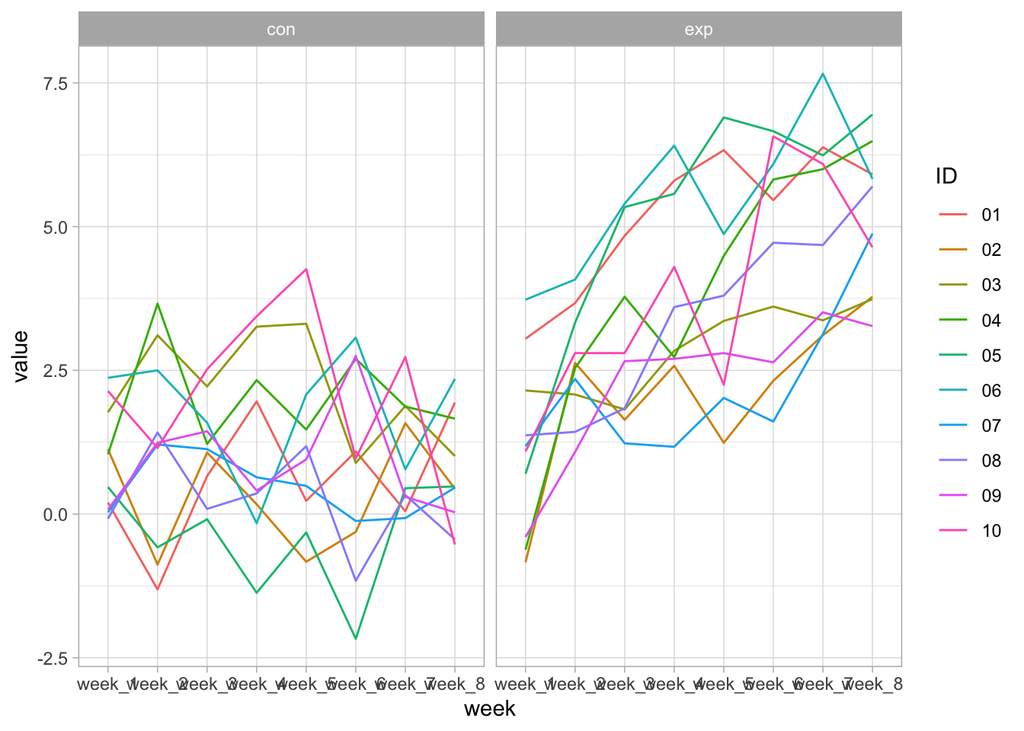

```r
data%>%
  pivot_longer(
    week_1:week_8,
    names_to = "week",
    values_to = "value"
  )%>%
  ggplot(aes(x=week, y=value, group=ID, color=ID))+ geom_line() +facet_wrap("arm") +
  theme_light()
```

Based on the spaghetti plot above, case and control group show different trend. The subjects in experiment group show noticeable increase as weeks go by. In contrast, for control group, even though the value move around as weeks go by there is no clear trend/tendency.